# R-INLA를 이용한 공간자료분석 1

# 자료 소개

네가지 형태의 자료를 고려한다.

1. Regular lattice
2. Irregular lattice
3. Geostatistical data
4. Point patterns

# Regular lattice

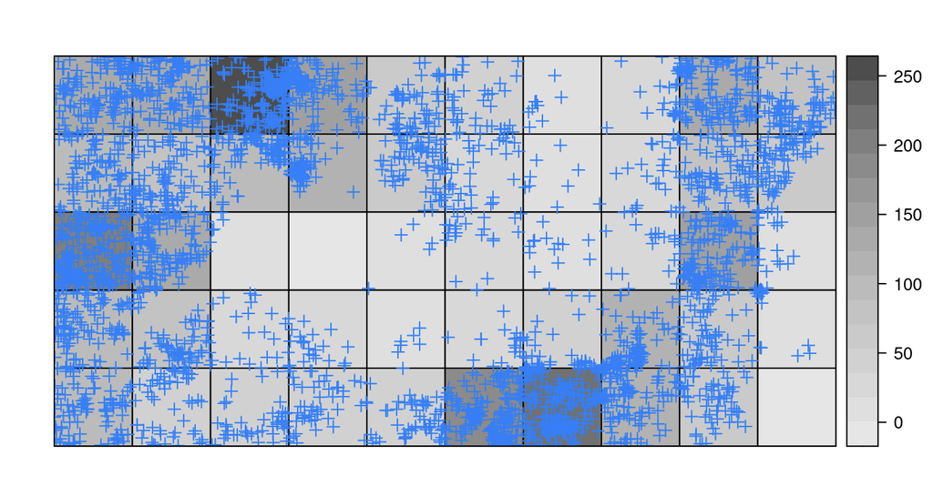

- $Y$ : number of trees
- $X$ : 지리적 특성
- 오차항 : correlated되어있음 (공간정보반영)

# Irregular lattice

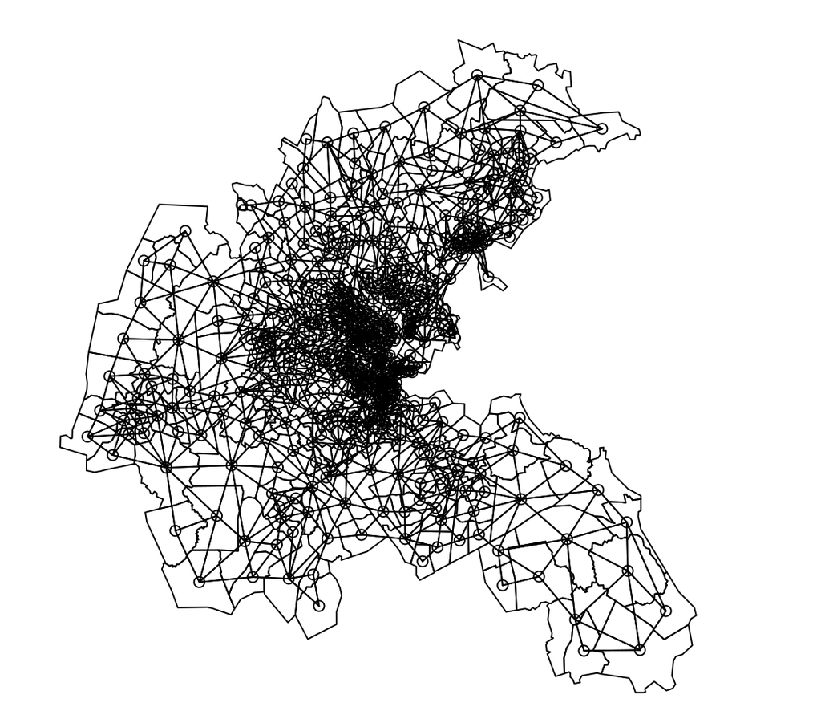

- $Y$ : 집값
- $X$ : 지역적 특성 (범죄율 등)
- 오차항 : correlated되어있음 (공간정보반영)

# Geostatistical data

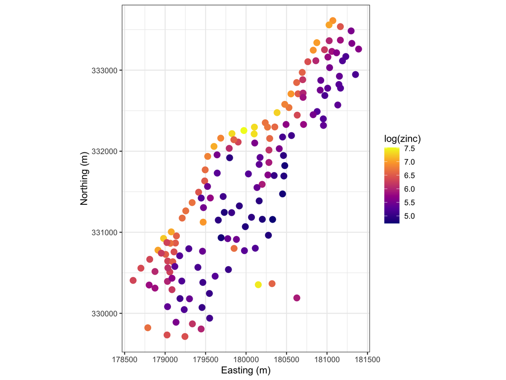

- $Y$ : Zinc 농도
- $X$ : 강과의 거리
- 오차항 : correlated되어있음 (공간정보반영)

# Point patterns

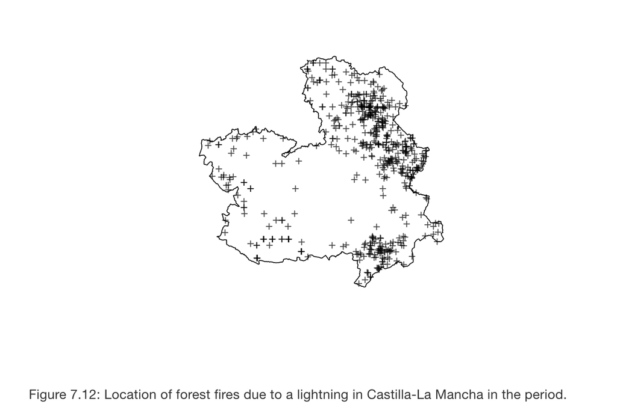

# 분석 목적

- $Y$에 따른 $X$ 회귀분석 수행
- 오차항의 공간적 패턴 파악

# 1. Regular lattice

자료 형태

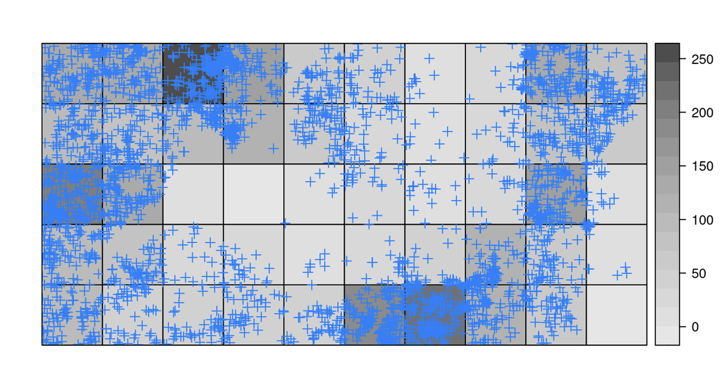